# Desempenho dos alunos do 5º ano no Saeb 2023: análise descritiva

Eixo 4 — Educação Básica Municipal (parceria SME Curitiba) · Projetos de Análise de Dados 2026/2

01/10/2026

# 1 Introdução

O Sistema de Avaliação da Educação Básica (Saeb), conduzido pelo Inep, avalia periodicamente o aprendizado dos estudantes brasileiros em Língua Portuguesa e Matemática. Além das provas, os alunos respondem a um questionário sobre seu perfil, sua família, sua rotina e sua percepção da escola, o que permite relacionar o desempenho a fatores de contexto.

Este trabalho, desenvolvido no âmbito do Eixo 4: Educação Básica Municipal, em parceria com a Secretaria Municipal de Educação de Curitiba (SME), utiliza os microdados do Saeb 2023 para os alunos do 5º ano do Ensino Fundamental. O foco está nos alunos com desempenho abaixo do nível básico, isto é, que não atingiram o mínimo de aprendizado esperado para a etapa.

As perguntas que orientam a análise são:

1. Qual a proporção de alunos do 5º ano abaixo do nível básico em Língua Portuguesa e em Matemática?
2. Quais características dos alunos, de suas famílias, de sua rotina e de sua relação com a escola estão associadas a estar abaixo do nível básico?
3. Como Curitiba se compara ao Brasil nesses aspectos? (A ser revisada pelo professor e André)

Este relatório parcial apresenta a etapa descritiva. As associações identificadas aqui servirão de base para a etapa seguinte, de modelagem por regressão logística.

# 2 Dados e metodologia

> Rascunho para revisão do grupo.

## 2.1 Fonte dos dados

Foram utilizados os microdados do Saeb 2023 disponibilizados pelo Inep, arquivo `TS_ALUNO_5EF`, com uma linha por aluno do 5º ano: 2.442.143 alunos e 152 variáveis, entre identificação, controle da aplicação, proficiências e as respostas ao questionário do aluno. A descrição de todas as variáveis está no codebook do projeto (`docs/codebook.md`), gerado a partir do dicionário oficial do Inep.

## 2.2 Amostra Brasil

Pelo tamanho da base, foi sorteada uma amostra estratificada por Unidade da Federação, com alocação proporcional ao número de alunos de cada UF, totalizando 32.000 alunos. Escolhemos utilizar a proporção de alunos por UF na base e não uma proporção estadual populacional. Utilizamos semente fixa (`set.seed(123)`) para garantir a reprodutibilidade da mesma amostra.

## 2.3 Filtros de qualidade

Foram mantidos apenas os alunos que:

- tinham situação consistente com o Censo Escolar;
- estiveram presentes e preencheram as provas de Língua Portuguesa e Matemática;
- tiveram proficiência calculada nas duas disciplinas;
- preencheram o questionário do aluno e responderam a todas as suas 70 questões, sem respostas em branco ou inválidas.

Após os filtros, a amostra Brasil ficou com 10.068 alunos. (Foi escolhido o 32000 para sobrar essa quantidade)

### 2.3.1 Efeito dos filtros na base completa

A tabela abaixo mostra quantos alunos cada filtro remove quando aplicado à base completa do Inep (`R/03`).

| Etapa | Alunos | Removidos | % restante |
| --- | --- | --- | --- |
| Base original | 2.442.143 |  | 100,0% |
| Situação consistente no Censo | 2.433.404 | 8.739 | 99,6% |
| Presente nas provas de LP e MT | 2.096.324 | 337.080 | 85,8% |
| Preencheu as provas de LP e MT | 2.081.291 | 15.033 | 85,2% |
| Tem proficiência em LP e MT | 2.081.287 | 4 | 85,2% |
| Preencheu o questionário | 2.063.719 | 17.568 | 84,5% |
| Respondeu todas as 70 questões | 761.673 | 1.302.046 | 31,2% |

### 2.3.2 Limitação: viés do questionário completo

A exigência de questionário completo é o filtro mais restritivo: os alunos excluídos por ela têm desempenho inferior e uma proporção bem maior de alunos abaixo do nível básico. Assim, as proporções apresentadas neste relatório tendem a subestimar a parcela real de alunos abaixo do básico. Nós optamos por manter o filtro, aplicando a mesma regra a Brasil e Curitiba para que a comparação entre eles seja justa.

| Grupo | Alunos | Média LP | Média MT | Abaixo do básico LP | Abaixo do básico MT |
| --- | --- | --- | --- | --- | --- |
| Brasil — questionário completo (mantidos) | 761.673 | 224 | 236 | 7,9% | 11,3% |
| Brasil — alguma questão em branco (excluídos) | 1.302.046 | 200 | 210 | 19,5% | 27,0% |
| Curitiba — questionário completo (mantidos) | 4.452 | 233 | 246 | 4,2% | 6,8% |
| Curitiba — todos com nota válida | 13.973 | 219 | 231 | 9,0% | 12,8% |

## 2.4 Variáveis resposta

A proficiência do Saeb foi convertida em duas variáveis dicotômicas, a partir dos cortes de nível de aprendizado propostos por Soares (2009) para o 5º ano:

| Nível de aprendizado | Língua Portuguesa | Matemática |
| --- | --- | --- |
| Abaixo do básico | até 150 | até 175 |
| Básico | mais de 150 a 200 | mais de 175 a 200 |
| Adequado | mais de 200 a 250 | mais de 200 a 225 |
| Avançado | mais de 250 | mais de 225 |

- `abaixo_LP` = 1 se a proficiência em Língua Portuguesa for menor ou igual a 150, e 0 caso contrário;
- `abaixo_MT` = 1 se a proficiência em Matemática for menor ou igual a 175, e 0 caso contrário.

Segundo Soares (2009), espera-se que no máximo 5% dos alunos estejam abaixo do nível básico.

## 2.5 Bases de treino e teste

Pensando na etapa de modelagem, a amostra Brasil foi dividida em treino (90%, 9.062 alunos) e teste (10%, 1.006 alunos), com sorteio estratificado pelas duas variáveis resposta. Todas as análises deste relatório usam apenas a base de treino; a base de teste fica reservada para a avaliação final do modelo.

## 2.6 Recorte Curitiba

Como a amostra Brasil contém poucos alunos de Curitiba, foi construída uma base separada com todos os alunos da cidade (UF = Paraná e área = capital), aplicando os mesmos filtros: 4.452 alunos em 190 escolas, 98,6% delas públicas. A base não permite distinguir escolas municipais de estaduais.

## 2.7 Ferramentas e organização do código

Toda a análise foi feita em R (pacotes `tidyverse` e `scales`), com o código versionado no GitHub. Os scripts ficam na pasta `R/` e foram numerados na ordem em que as etapas da análise acontecem: como os arquivos são exibidos em ordem numérica e alfabética, a própria listagem da pasta mostra a sequência de execução, e cada script usa as bases geradas pelos anteriores. Rodando-os nessa ordem, todas as bases e resultados são reproduzidos a partir dos microdados do Inep.

| Script | Etapa | Produz |
| --- | --- | --- |
| `00_codebook.R` | Documentação das variáveis a partir do dicionário do Inep | `docs/codebook.csv`, `docs/codebook.md` |
| `01 Preparação Base .R` | Amostra estratificada por UF, filtros de qualidade e variáveis resposta | `data/amostra_limpa.csv` |
| `02 Separação bases.R` | Divisão em treino (90%) e teste (10%) | `data/treino.csv`, `data/teste.csv` |
| `03 Teste viés.R` | Diagnóstico do efeito dos filtros na base completa | resultados no console |
| `04 Descritiva Geral.R` | Análise descritiva da amostra Brasil | tabelas e gráficos |
| `05 Base curitiba.R` | Base com todos os alunos de Curitiba, com os mesmos filtros | `data/curitiba_limpa.csv` |
| `06 Comparação Curitiba.R` | Comparação Curitiba × Brasil | tabelas e gráficos |
| `07 Fatores associados.R` | Força da associação das variáveis selecionadas com estar abaixo do básico | tabelas e gráficos |

Este relatório fica na pasta `Entregas/` e reúne os resultados dessas etapas.

# 3 Resultados — Brasil

## 3.1 Proficiência em Língua Portuguesa e Matemática

| Disciplina | Média | Mediana | Desvio padrão | Mínimo | 1º quartil | 3º quartil | Máximo |
| --- | --- | --- | --- | --- | --- | --- | --- |
| Língua Portuguesa | 223,4 | 224,0 | 49,1 | 98,0 | 188,9 | 258,6 | 345,1 |
| Matemática | 236,3 | 235,4 | 49,6 | 99,9 | 200,9 | 270,4 | 366,8 |

As notas das duas disciplinas têm distribuição aproximadamente simétrica (média e mediana praticamente iguais) e dispersão semelhante. A linha tracejada marca o corte do nível básico.

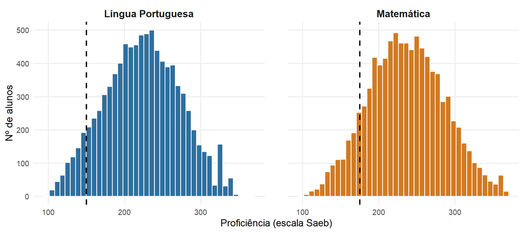

## 3.2 Alunos abaixo do nível básico

Na amostra Brasil, 7,7% dos alunos estão abaixo do nível básico em Língua Portuguesa e 11,0% em Matemática, ambos acima da expectativa de 5%.

| Situação | Alunos | % dos alunos |
| --- | --- | --- |
| Abaixo nas duas | 378 | 4,2% |
| Abaixo só em LP | 316 | 3,5% |
| Abaixo só em MT | 622 | 6,9% |
| Básico ou acima nas duas | 7.746 | 85,5% |

As notas de LP e MT são fortemente correlacionadas (r = 0,69). As linhas tracejadas dividem o gráfico nos quatro grupos da tabela acima.

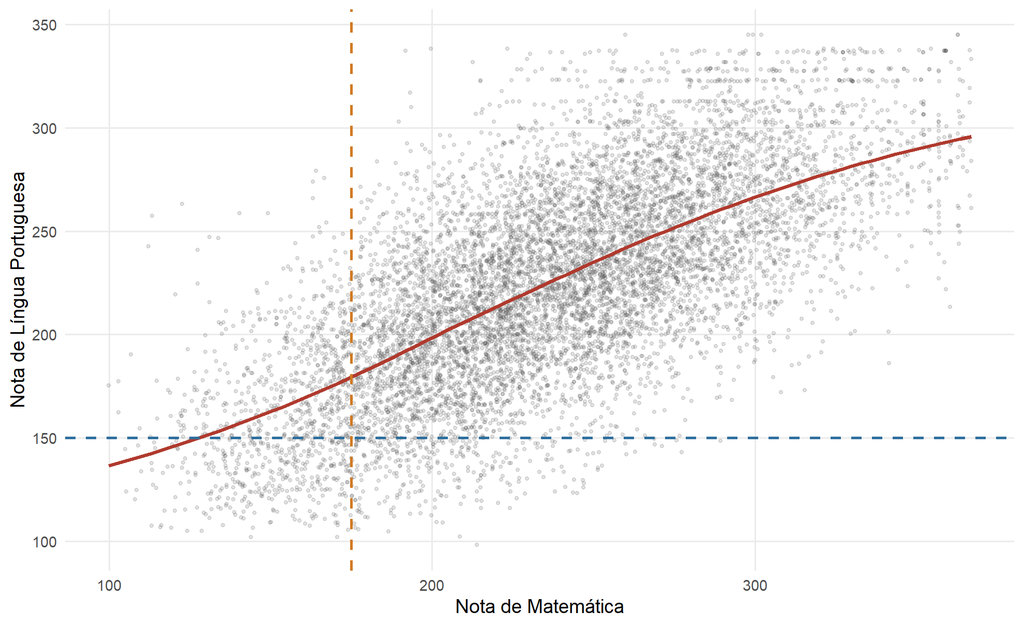

## 3.3 Alunos abaixo do básico por característica

Para cada variável são apresentados: a pergunta do questionário, a distribuição dos alunos e a proporção abaixo do nível básico em cada categoria, um gráfico de barras dessa proporção (a linha tracejada é a média geral) e o boxplot das notas (a linha tracejada é o corte do nível básico). As variáveis marcadas com ★ foram selecionadas pelo grupo como mais relevantes.

### 3.3.1 Características do aluno

#### Sexo

*Qual é o seu sexo?* (`TX_RESP_Q01`)

| Categoria | Alunos | % dos alunos | Abaixo do básico LP | Abaixo do básico MT |
| --- | --- | --- | --- | --- |
| Masculino | 4.310 | 47,6% | 8,8% | 9,8% |
| Feminino | 4.567 | 50,4% | 6,0% | 11,4% |
| Não quero declarar | 185 | 2,0% | 21,1% | 31,4% |

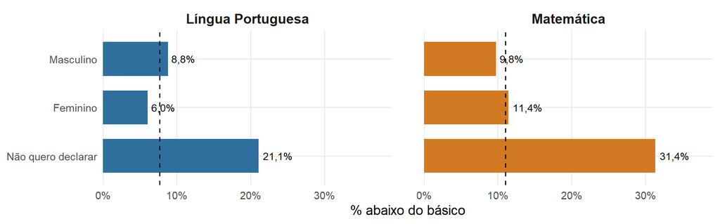

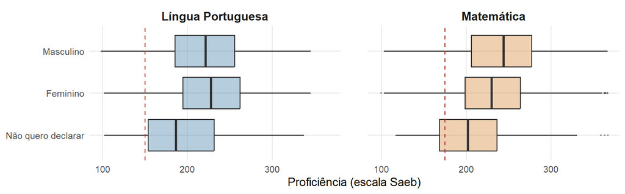

#### Cor/raça

*Qual é a sua cor ou raça?* (`TX_RESP_Q04`)

| Categoria | Alunos | % dos alunos | Abaixo do básico LP | Abaixo do básico MT |
| --- | --- | --- | --- | --- |
| Branca | 2.765 | 30,5% | 5,7% | 7,7% |
| Preta | 887 | 9,8% | 13,0% | 18,5% |
| Parda | 4.522 | 49,9% | 7,3% | 10,9% |
| Amarela | 163 | 1,8% | 12,3% | 12,9% |
| Indígena | 147 | 1,6% | 7,5% | 15,6% |
| Não quero declarar | 578 | 6,4% | 10,2% | 14,5% |

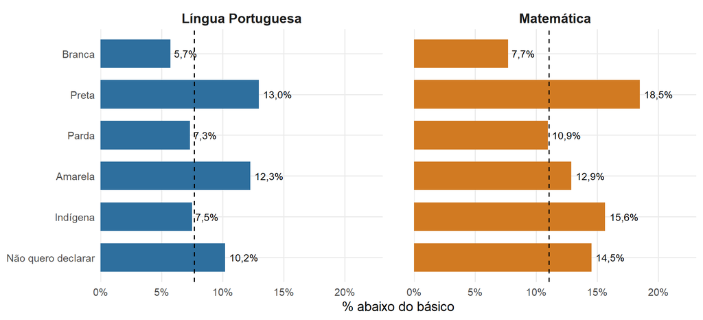

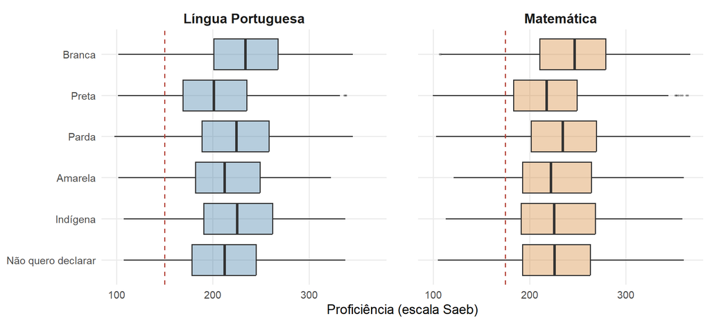

#### Idade ★

*Qual é a sua idade?* (`TX_RESP_Q02`)

| Categoria | Alunos | % dos alunos | Abaixo do básico LP | Abaixo do básico MT |
| --- | --- | --- | --- | --- |
| 9 anos ou menos | 46 | 0,5% | 13,0% | 17,4% |
| 10 anos | 3.746 | 41,3% | 6,4% | 9,6% |
| 11 anos | 4.602 | 50,8% | 6,6% | 9,7% |
| 12 anos | 457 | 5,0% | 19,9% | 24,1% |
| 13 anos | 140 | 1,5% | 20,7% | 31,4% |
| 14 anos ou mais | 71 | 0,8% | 31,0% | 43,7% |

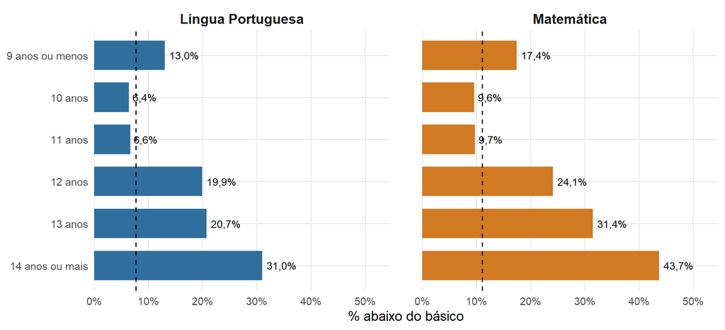

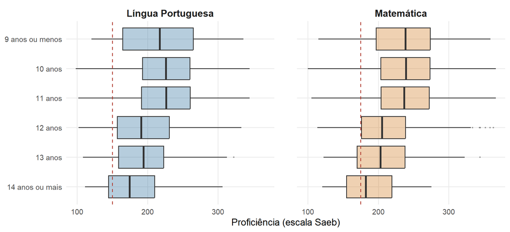

#### Reprovação ★

*Você já foi reprovado(a)?* (`TX_RESP_Q19`)

| Categoria | Alunos | % dos alunos | Abaixo do básico LP | Abaixo do básico MT |
| --- | --- | --- | --- | --- |
| Não | 8.141 | 89,8% | 6,3% | 9,2% |
| Sim, uma vez | 721 | 8,0% | 20,9% | 25,1% |
| Sim, duas vezes ou mais | 200 | 2,2% | 16,0% | 33,0% |

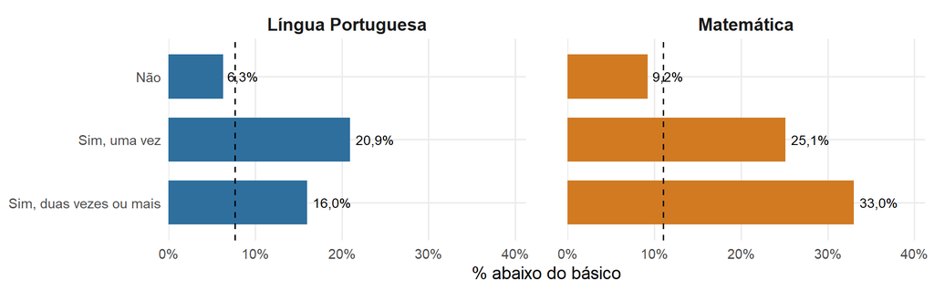

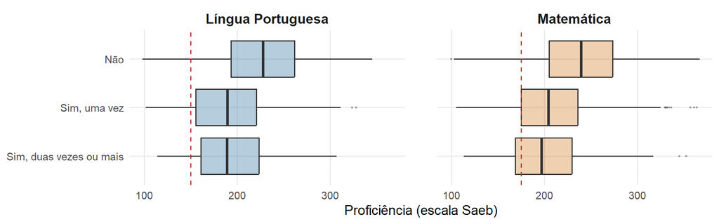

#### Abandono escolar

*Alguma vez você abandonou a escola deixando de frequentá-la até o final do ano escolar?* (`TX_RESP_Q20`)

| Categoria | Alunos | % dos alunos | Abaixo do básico LP | Abaixo do básico MT |
| --- | --- | --- | --- | --- |
| Nunca | 8.509 | 93,9% | 7,1% | 10,5% |
| Sim, uma vez | 427 | 4,7% | 14,8% | 17,6% |
| Sim, duas vezes ou mais | 126 | 1,4% | 20,6% | 26,2% |

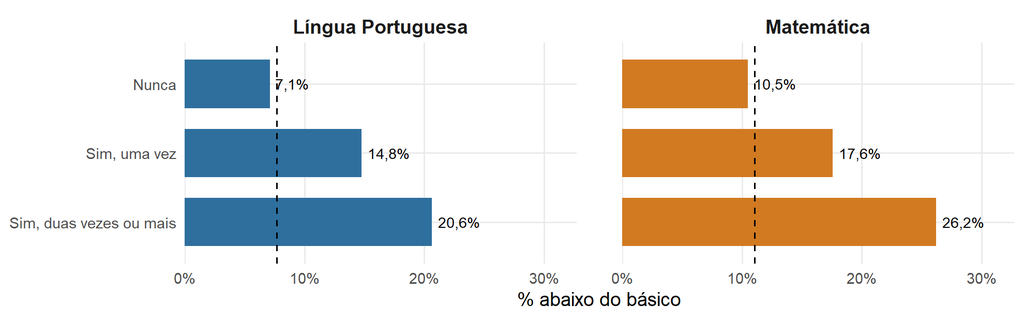

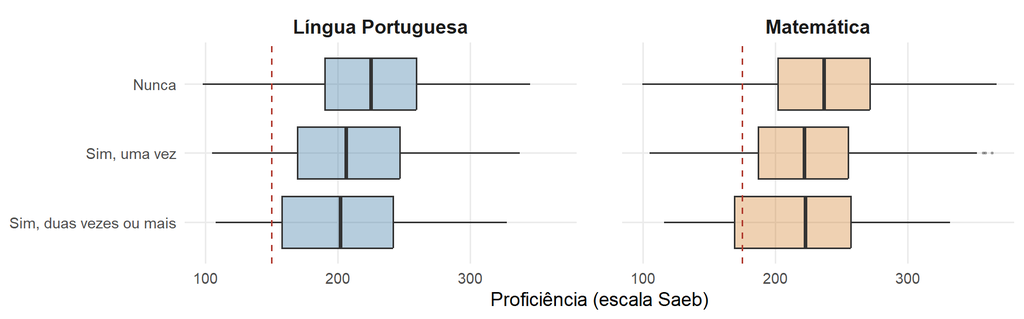

#### Idade de entrada na escola ★

*Com que idade você entrou na escola?* (`TX_RESP_Q17`)

| Categoria | Alunos | % dos alunos | Abaixo do básico LP | Abaixo do básico MT |
| --- | --- | --- | --- | --- |
| 3 anos ou menos | 3.891 | 42,9% | 7,2% | 9,5% |
| 4 ou 5 anos | 3.333 | 36,8% | 6,9% | 10,7% |
| 6 ou 7 anos | 1.391 | 15,3% | 7,8% | 12,4% |
| 8 anos ou mais | 447 | 4,9% | 16,6% | 21,9% |

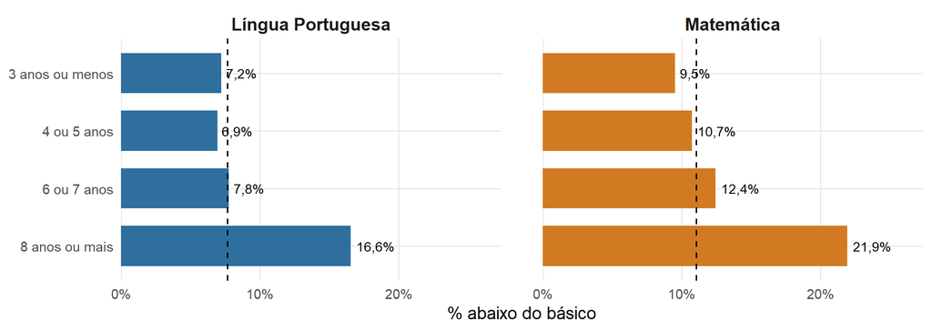

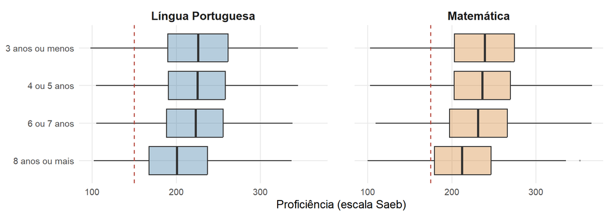

#### Deficiência

*Você possui deficiência, transtorno do espectro autista ou superdotação? - Deficiência.* (`TX_RESP_Q05a`)

| Categoria | Alunos | % dos alunos | Abaixo do básico LP | Abaixo do básico MT |
| --- | --- | --- | --- | --- |
| Não | 8.813 | 97,3% | 7,4% | 10,6% |
| Sim | 249 | 2,7% | 17,7% | 26,1% |

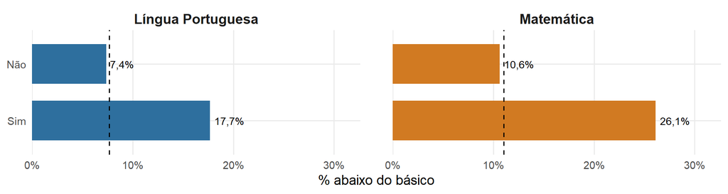

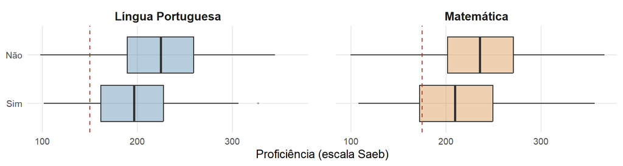

#### Transtorno do espectro autista

*Você possui deficiência, transtorno do espectro autista ou superdotação? - Transtorno do espectro autista.* (`TX_RESP_Q05b`)

| Categoria | Alunos | % dos alunos | Abaixo do básico LP | Abaixo do básico MT |
| --- | --- | --- | --- | --- |
| Não | 8.849 | 97,6% | 7,5% | 10,6% |
| Sim | 213 | 2,4% | 16,0% | 27,2% |

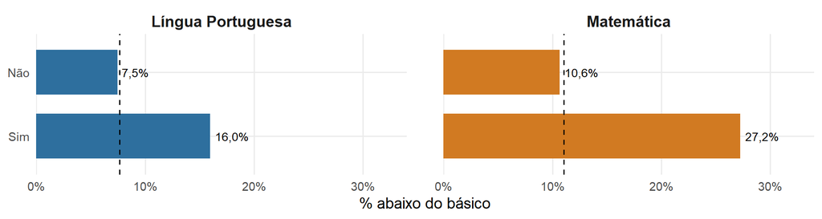

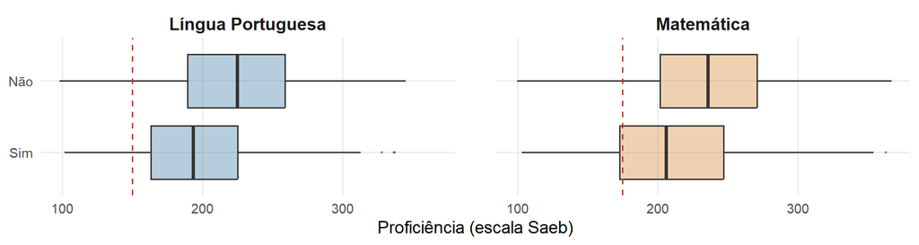

#### Altas habilidades

*Você possui deficiência, transtorno do espectro autista ou superdotação? - Altas habilidades ou superdotação.* (`TX_RESP_Q05c`)

| Categoria | Alunos | % dos alunos | Abaixo do básico LP | Abaixo do básico MT |
| --- | --- | --- | --- | --- |
| Não | 8.338 | 92,0% | 7,4% | 10,9% |
| Sim | 724 | 8,0% | 10,5% | 12,8% |

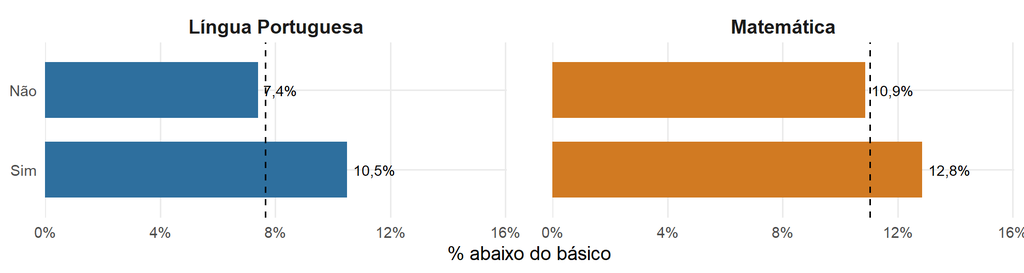

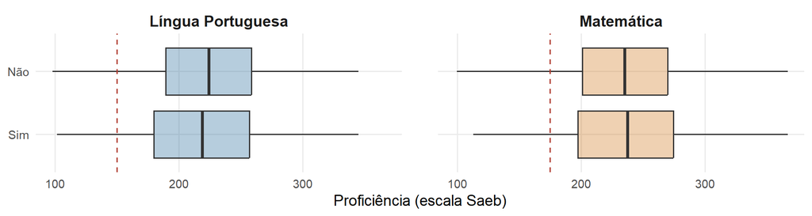

### 3.3.2 Idade agrupada

Agrupando as idades, fica mais claro o efeito da distorção idade-série: alunos com 12 anos ou mais, que em geral estão atrasados em relação à série, concentram uma proporção muito maior de alunos abaixo do básico.

| Idade | Alunos | % dos alunos | Abaixo do básico LP | Abaixo do básico MT |
| --- | --- | --- | --- | --- |
| 9 anos ou menos | 46 | 0,5% | 13,0% | 17,4% |
| 10 e 11 anos | 8.348 | 92,1% | 6,5% | 9,7% |
| 12 anos ou mais | 668 | 7,4% | 21,3% | 27,7% |

### 3.3.3 Ambiente familiar e entorno

#### Mora com a mãe ★

*Normalmente, quem mora na sua casa? - Mãe(s) ou madrasta(s).* (`TX_RESP_Q07a`)

| Categoria | Alunos | % dos alunos | Abaixo do básico LP | Abaixo do básico MT |
| --- | --- | --- | --- | --- |
| Não | 909 | 10,0% | 13,9% | 18,0% |
| Sim | 8.153 | 90,0% | 7,0% | 10,3% |

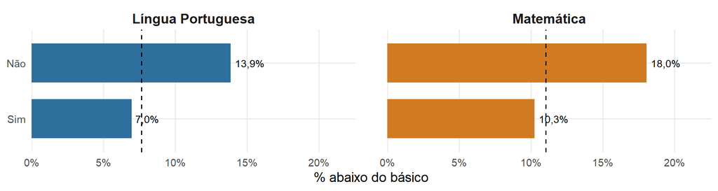

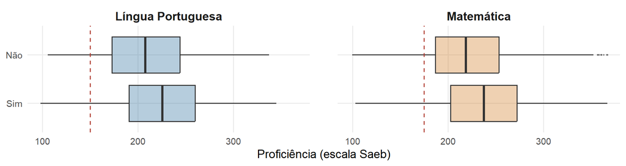

#### Mora com o pai ★

*Normalmente, quem mora na sua casa? - Pai(s) ou padrasto(s).* (`TX_RESP_Q07b`)

| Categoria | Alunos | % dos alunos | Abaixo do básico LP | Abaixo do básico MT |
| --- | --- | --- | --- | --- |
| Não | 2.436 | 26,9% | 10,1% | 14,3% |
| Sim | 6.626 | 73,1% | 6,8% | 9,8% |

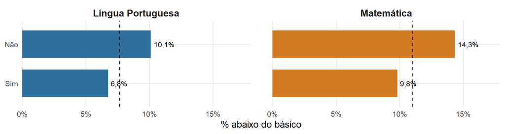

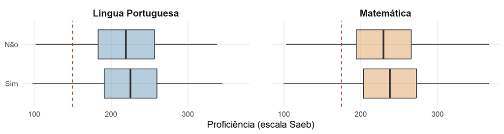

#### Nível socioeconômico (INSE) ★

*Classificação do Indicador de Nível Socioeconômico em 8 Grupos* (`NU_TIPO_NIVEL_INSE`)

| Categoria | Alunos | % dos alunos | Abaixo do básico LP | Abaixo do básico MT |
| --- | --- | --- | --- | --- |
| Nível I | 103 | 1,1% | 25,2% | 36,9% |
| Nível II | 973 | 10,7% | 15,0% | 22,1% |
| Nível III | 1.520 | 16,8% | 10,4% | 15,9% |
| Nível IV | 2.033 | 22,4% | 7,0% | 10,3% |
| Nível V | 1.981 | 21,9% | 6,3% | 8,3% |
| Nível VI | 1.330 | 14,7% | 4,6% | 6,1% |
| Nível VII | 978 | 10,8% | 3,0% | 4,3% |
| Nível VIII | 144 | 1,6% | 4,2% | 5,6% |

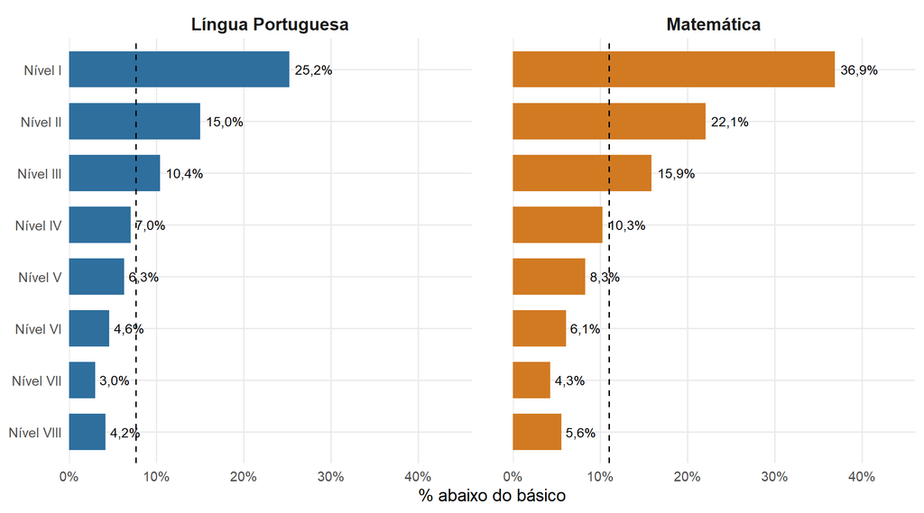

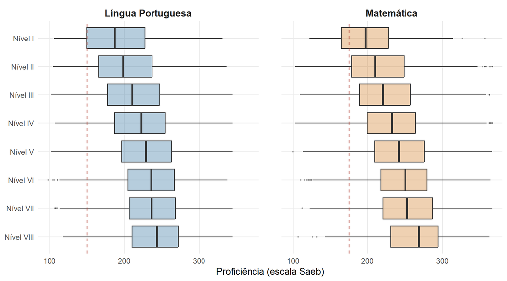

#### Tipo de escola desde o 1º ano

*A partir do primeiro ano do ensino fundamental, em que tipo de escola você estudou?* (`TX_RESP_Q18`)

| Categoria | Alunos | % dos alunos | Abaixo do básico LP | Abaixo do básico MT |
| --- | --- | --- | --- | --- |
| Somente em escola pública | 7.222 | 79,7% | 7,0% | 10,5% |
| Somente em escola particular | 496 | 5,5% | 14,5% | 18,1% |
| Em escola pública e em escola particular | 1.344 | 14,8% | 8,6% | 11,3% |

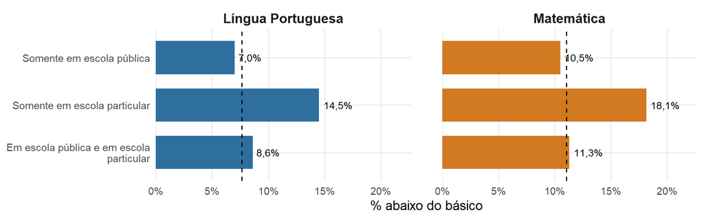

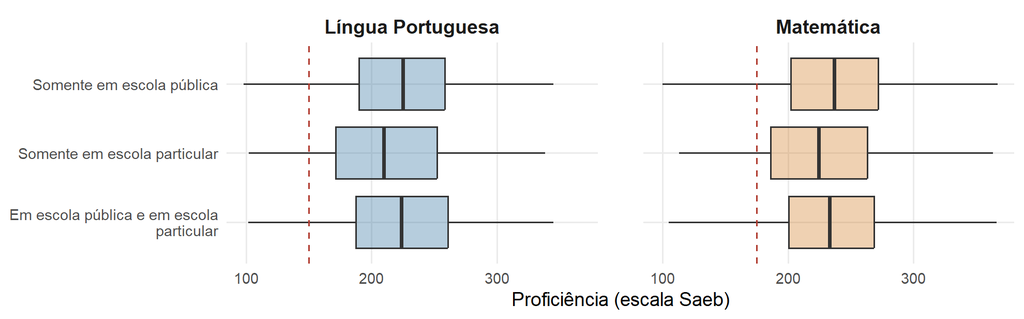